# Flights Dataset Exploration

## by Tokhir

## Investigation Overview

> This presentation is intended to cover the main fragments of the exploration. Here the Univariate Exploration, Bivariate Exploration and Multivariate Exploration related to the flight database will be considered. Then we will get the answers to the questions I have posed.How many flights are there every month, every day of the week, every day of the month?

> *How many flights are there every month, every day of the week, every day of the month?*

> *Most frequent flight distance*

> *Most common reasons for canceled flights*

> *At which airports the most frequent flight cancellations occur?*

> *Is there a relationship between the departure time of the aircraft and the distance?*

> *What days are the most frequent delays (in minutes)?*

> ...

## Dataset Overview

> This dataset reports flights inside the country in the United States, including carriers, arrival and departure delays, and reasons for delays, 2008. This dataset consist of slightly more 7 million rows and 29 columns.

## Distribution of flights by Months, Days of Week and Days of Months

Looking at the distribution of flights by days of the month, you can understand that flights are distributed approximately evenly, excluding 31 and 30 numbers. This is due to leap and common years and the alternation of 30 and 31 numbers in each month. As for flights by months, the frequency of flights decreases towards the end of the year and reaches its peak in summer due to the number of people who want to fly away on vacation. Flights occur more often on weekdays than on weekends

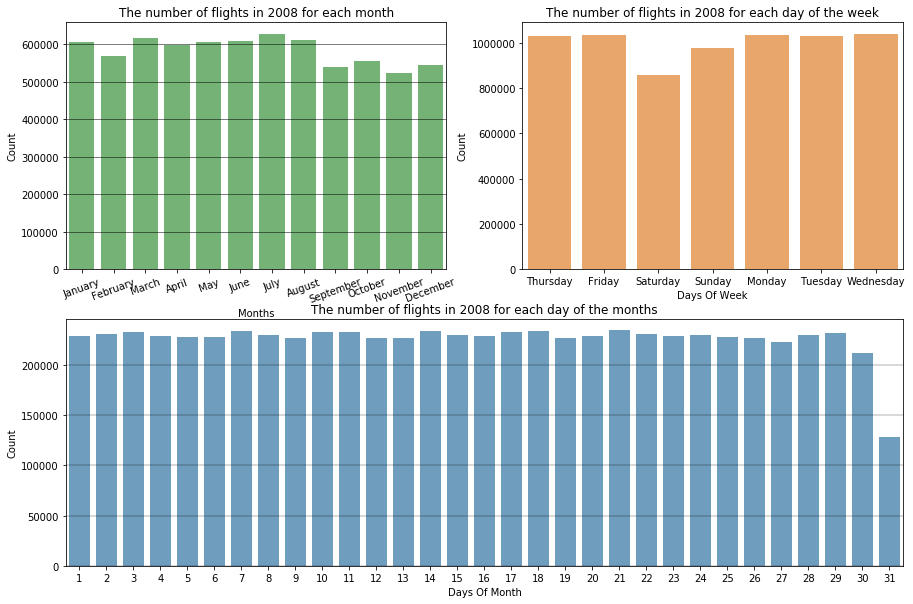

## Distribution of Distance

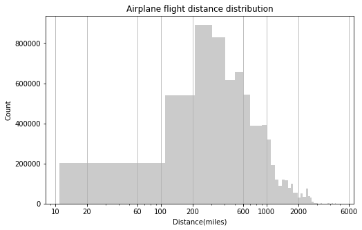

## Canselled Flights vs Months

On this diagram, the canceled flights due to the weather that occur in huge quantities, especially in December and February, are immediately evident. It is no secret to anyone that the weather in winter is not very suitable for aviation. Сanceled flights due to weather become minimal only in late spring and autumn. It is also worth noting the canceled flights due to carrier(most canceled flights by month-7), which are the most frequent this year. Due to the fact that flights canceled due to security are very small, they could not be displayed on this graph.

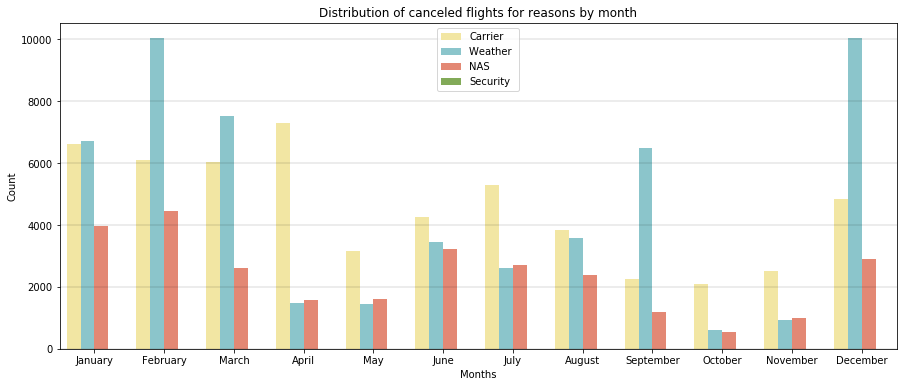

## Airports by averrage Departure Delay(top-20 by this indicator) in minutes and Months

Looking at the heat map, you can see that delays in flights at some airports were noticed only in a few months, but due to the size they got into this top. But there are also airports in which systematically, that is, every month, there are delays in flights. it is worth noting that the 3 longest departure delays were seen in winter. This is not surprising because as we saw, in winter the most frequent flight cancellations occur, most often due to the weather.

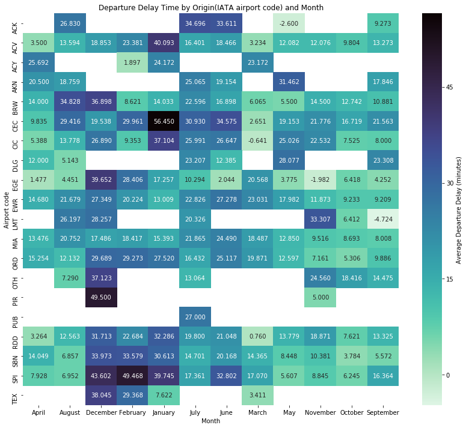